# Chapter

Suvi Vainio

17 marraskuuta 2018

# Clustering and classification

Boston dataset, that is used in this exercise, is available in the package MASS. Dataset has 506 rows and 14 variables The dataset has information on the factors that effect housing prices in the suburbs of Bosto, that is: crime rate, business, nature, pollution, average size of housing in the are and so on.

Summary and graphical overview of the data is in the graph below.

There are some clear and interesting linear (or polynomial) relationships in the data, for example houses that have more rooms [rm] tend to be more expensive in the median value [medv].

Also houses tend be more expensive if the proportion of population in the lower status [lstat] is low. Interestingly the proportion of the population goes up as the pollution [nox] goes up but median value of the housing goes down with high pollution.

Boston in the 1970s was clearly not one of the towns where the inner city is the most expensive neighbourhood.

```r
print(summary(Boston))
```

```
##       crim                zn             indus            chas
##  Min.   : 0.00632   Min.   :  0.00   Min.   : 0.46   Min.   :0.00000
##  1st Qu.: 0.08204   1st Qu.:  0.00   1st Qu.: 5.19   1st Qu.:0.00000
##  Median : 0.25651   Median :  0.00   Median : 9.69   Median :0.00000
##  Mean   : 3.61352   Mean   : 11.36   Mean   :11.14   Mean   :0.06917
##  3rd Qu.: 3.67708   3rd Qu.: 12.50   3rd Qu.:18.10   3rd Qu.:0.00000
##  Max.   :88.97620   Max.   :100.00   Max.   :27.74   Max.   :1.00000
##       nox               rm             age              dis
##  Min.   :0.3850   Min.   :3.561   Min.   :  2.90   Min.   : 1.130
##  1st Qu.:0.4490   1st Qu.:5.886   1st Qu.: 45.02   1st Qu.: 2.100
##  Median :0.5380   Median :6.208   Median : 77.50   Median : 3.207
##  Mean   :0.5547   Mean   :6.285   Mean   : 68.57   Mean   : 3.795
##  3rd Qu.:0.6240   3rd Qu.:6.623   3rd Qu.: 94.08   3rd Qu.: 5.188
##  Max.   :0.8710   Max.   :8.780   Max.   :100.00   Max.   :12.127
##       rad              tax           ptratio          black
##  Min.   : 1.000   Min.   :187.0   Min.   :12.60   Min.   :  0.32
##  1st Qu.: 4.000   1st Qu.:279.0   1st Qu.:17.40   1st Qu.:375.38
##  Median : 5.000   Median :330.0   Median :19.05   Median :391.44
##  Mean   : 9.549   Mean   :408.2   Mean   :18.46   Mean   :356.67
##  3rd Qu.:24.000   3rd Qu.:666.0   3rd Qu.:20.20   3rd Qu.:396.23
##  Max.   :24.000   Max.   :711.0   Max.   :22.00   Max.   :396.90
##      lstat            medv
##  Min.   : 1.73   Min.   : 5.00
##  1st Qu.: 6.95   1st Qu.:17.02
##  Median :11.36   Median :21.20
##  Mean   :12.65   Mean   :22.53
##  3rd Qu.:16.95   3rd Qu.:25.00
##  Max.   :37.97   Max.   :50.00
```

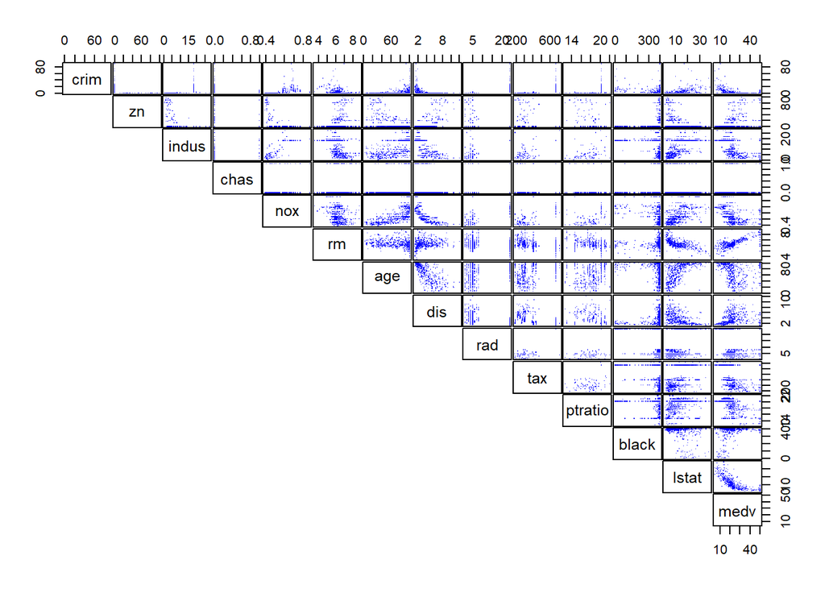

```r
pairs(Boston, lower.panel = NULL, col=alpha('blue', 0.8), gap=0.1, pch='.')
```

Standardizing a variable means that the variable is scaled to have a mean of 0 and standard deviation of 1. Boston dataset contains only numerical variables, so every column can be standardized. Here is a summary of the data after it has been standardized. Now every variable is on the same scale and can be compared to other variables more easily.

```
##       crim                 zn               indus
##  Min.   :-0.419367   Min.   :-0.48724   Min.   :-1.5563
##  1st Qu.:-0.410563   1st Qu.:-0.48724   1st Qu.:-0.8668
##  Median :-0.390280   Median :-0.48724   Median :-0.2109
##  Mean   : 0.000000   Mean   : 0.00000   Mean   : 0.0000
##  3rd Qu.: 0.007389   3rd Qu.: 0.04872   3rd Qu.: 1.0150
##  Max.   : 9.924110   Max.   : 3.80047   Max.   : 2.4202
##       chas              nox                rm               age
##  Min.   :-0.2723   Min.   :-1.4644   Min.   :-3.8764   Min.   :-2.3331
##  1st Qu.:-0.2723   1st Qu.:-0.9121   1st Qu.:-0.5681   1st Qu.:-0.8366
##  Median :-0.2723   Median :-0.1441   Median :-0.1084   Median : 0.3171
##  Mean   : 0.0000   Mean   : 0.0000   Mean   : 0.0000   Mean   : 0.0000
##  3rd Qu.:-0.2723   3rd Qu.: 0.5981   3rd Qu.: 0.4823   3rd Qu.: 0.9059
##  Max.   : 3.6648   Max.   : 2.7296   Max.   : 3.5515   Max.   : 1.1164
##       dis               rad               tax             ptratio
##  Min.   :-1.2658   Min.   :-0.9819   Min.   :-1.3127   Min.   :-2.7047
##  1st Qu.:-0.8049   1st Qu.:-0.6373   1st Qu.:-0.7668   1st Qu.:-0.4876
##  Median :-0.2790   Median :-0.5225   Median :-0.4642   Median : 0.2746
##  Mean   : 0.0000   Mean   : 0.0000   Mean   : 0.0000   Mean   : 0.0000
##  3rd Qu.: 0.6617   3rd Qu.: 1.6596   3rd Qu.: 1.5294   3rd Qu.: 0.8058
##  Max.   : 3.9566   Max.   : 1.6596   Max.   : 1.7964   Max.   : 1.6372
##      black             lstat              medv
##  Min.   :-3.9033   Min.   :-1.5296   Min.   :-1.9063
##  1st Qu.: 0.2049   1st Qu.:-0.7986   1st Qu.:-0.5989
##  Median : 0.3808   Median :-0.1811   Median :-0.1449
##  Mean   : 0.0000   Mean   : 0.0000   Mean   : 0.0000
##  3rd Qu.: 0.4332   3rd Qu.: 0.6024   3rd Qu.: 0.2683
##  Max.   : 0.4406   Max.   : 3.5453   Max.   : 2.9865
```

## Building a categorized dependent variable

For linear discriminant analysis the dependent variable need to be categorical. Below is first a histogram of the original continuous variable and then propensity table of the dependent variable when it is categorized according to quantile function.

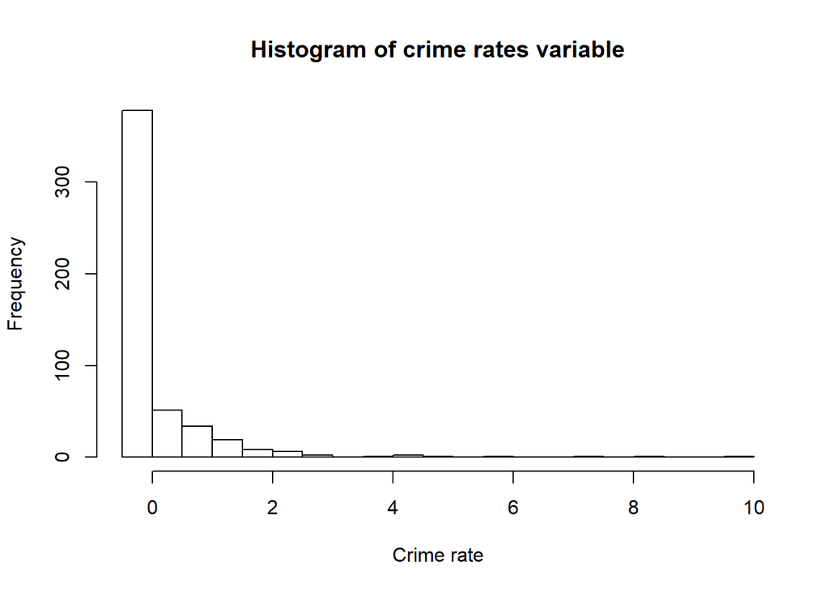

```
## [1] "Breaks are in points: "
```

```
##           0%          25%          50%          75%         100%
## -0.419366929 -0.410563278 -0.390280295  0.007389247  9.924109610
```

```
## [1] "Crime as categorized variable (%): "
```

```
## crime
##       low   med_low  med_high      high
## 0.2509881 0.2490119 0.2490119 0.2509881
```

## Linear discriminant analysis

The data is divided into train (80% of the rows) and test datasets.

Linear discriminanat analysis (LDA) is first fitted to the train dataset and the results are then tested with the second dataset. LDA assumes that each variable has the same variance and that variables are normally distributed (on condition of the classes). The former was achieved by standardizing the variables the latter is just assumed here.

Summary of the fitted model and corresponding plot are shown below. The arrow that didn’t fit into the plot corresponds to the variable indicating accessibility to radial highways [rad]. The length and the direction of the arrow indicates the impact of the variable - so here access to radial highways is strongly associated with higher crime rates.

```
## Call:
## lda(crim ~ ., data = train)
##
## Prior probabilities of groups:
##       low   med_low  med_high      high
## 0.2574257 0.2376238 0.2524752 0.2524752
##
## Group means:
##                  zn      indus        chas        nox          rm
## low       0.9800649 -0.9289932 -0.12090214 -0.8840876  0.38232091
## med_low  -0.1268043 -0.2827247  0.05576262 -0.5805175 -0.10606033
## med_high -0.3855121  0.1229837  0.11366115  0.3214262  0.06513871
## high     -0.4872402  1.0149946 -0.07933396  1.0504742 -0.39120833
##                 age        dis        rad        tax     ptratio
## low      -0.9283029  0.9004698 -0.6903373 -0.7186082 -0.41427359
## med_low  -0.4180492  0.3181246 -0.5595703 -0.5002463 -0.07424756
## med_high  0.3733164 -0.3538560 -0.4098896 -0.3384482 -0.30868153
## high      0.8361569 -0.8537265  1.6596029  1.5294129  0.80577843
##                black       lstat        medv
## low       0.38144794 -0.75097726  0.47233528
## med_low   0.35158204 -0.16718755  0.04003818
## med_high  0.06184429 -0.01919642  0.16730944
## high     -0.91715006  0.89174630 -0.67534711
##
## Coefficients of linear discriminants:
##                  LD1         LD2          LD3
## zn       0.125648813  0.71652027 -0.873606120
## indus    0.038197404 -0.31865408  0.452521675
## chas    -0.079118665 -0.05153935  0.139011977
## nox      0.228566356 -0.66823754 -1.427487726
## rm      -0.104565180 -0.06149069 -0.034365807
## age      0.317918371 -0.29202637 -0.368787824
## dis     -0.073835476 -0.14254622 -0.004810482
## rad      3.406794121  0.79573175  0.063962518
## tax     -0.004229489  0.16742497  0.434004959
## ptratio  0.118909820  0.08718021 -0.226751288
## black   -0.160715829 -0.01619556  0.157548433
## lstat    0.156114794 -0.22931607  0.410426650
## medv     0.152043879 -0.38043434 -0.202071648
##
## Proportion of trace:
##    LD1    LD2    LD3
## 0.9527 0.0361 0.0113
```

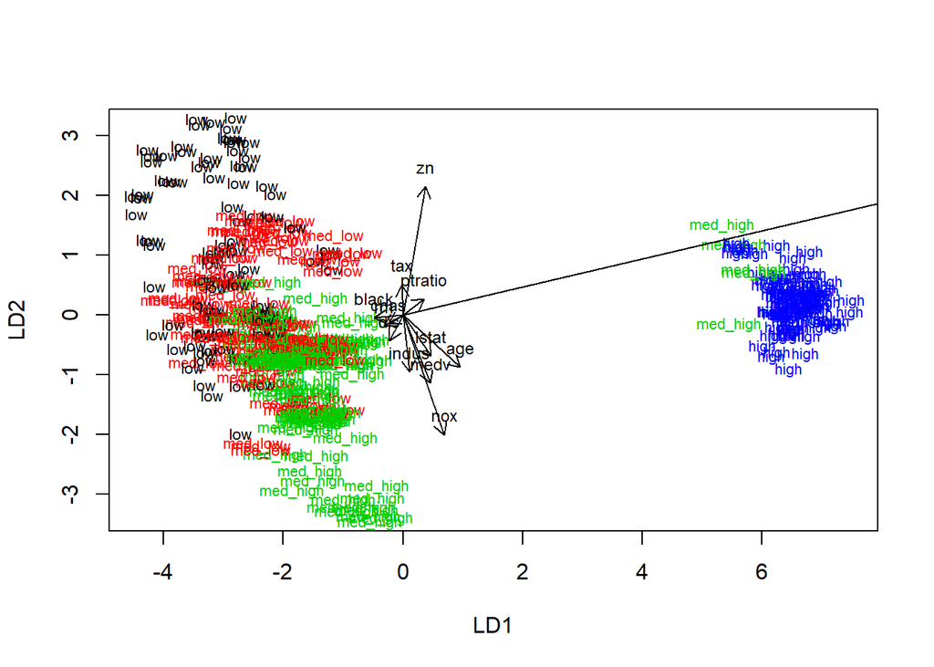

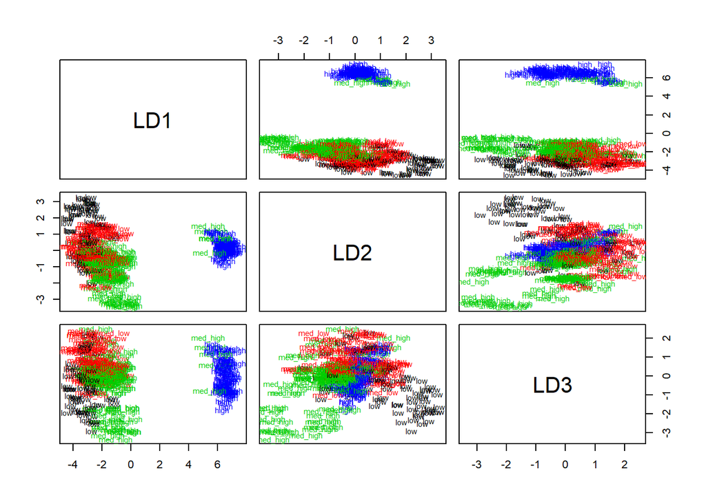

And indeed the high crime rate group is clearly recognizable from the plots (above), where LD1 is on one of the axes. When LD2 and LD3 are plotted on the same plot, all categories are more mixed together and the groups are not as easily identidiable.

When you look at the values, the heaviest load in LD1 is rad.

## Testing the model

```r
crimeTest=test$crim
test <- dplyr::select(test, -crim)
lda.pred <- predict(bostonFit, newdata = test)

table(correct = crimeTest, predicted = lda.pred$class)
```

```
##           predicted
## correct    low med_low med_high high
##   low       12       9        2    0
##   med_low    4      14       12    0
##   med_high   0       3       20    1
##   high       0       0        1   24
```

```r
# cross tabulate the results
table(correct = crimeTest, predicted = lda.pred$class)%>%prop.table(1)*100
```

```
##           predicted
## correct          low   med_low  med_high      high
##   low      52.173913 39.130435  8.695652  0.000000
##   med_low  13.333333 46.666667 40.000000  0.000000
##   med_high  0.000000 12.500000 83.333333  4.166667
##   high      0.000000  0.000000  4.000000 96.000000
```

## K-means clustering

Last task of the week is to fit k-means clustering to the standardized Boston dataset. Line plot below visualizes the clusters. Since there’s a clear drop between 1 cluster and 2 clusters I decide to go the simple way: my choice of optimal number of clusters is 2.

Of course you could go with three or even four might be interesting, but the drop in the sum of squares is not so great then.

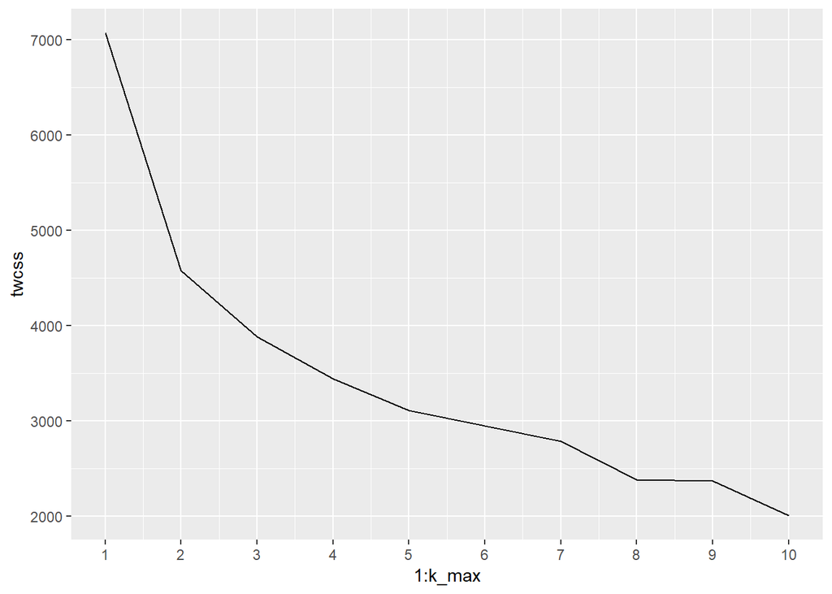

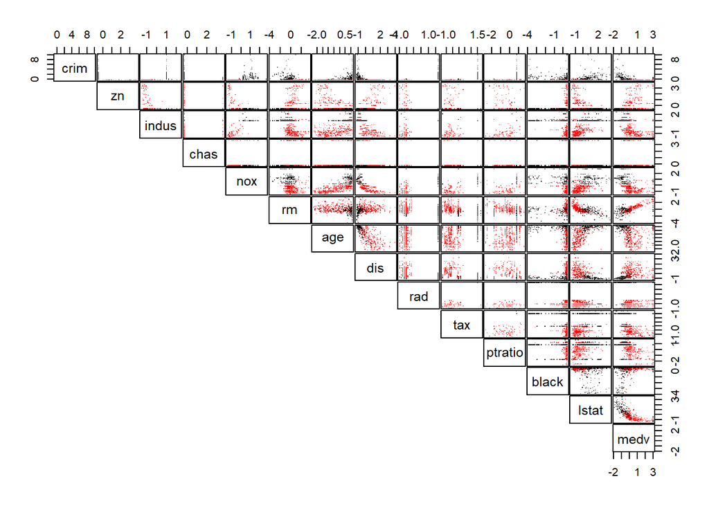